# IFLS BMI MAIHDA

Intersectionality is the study of how multiple sociodemographic identities intersect and interact to create unique experiences of discrimination and privilege that result in inequalities in individual outcomes. Intersectionality makes visible the experiences of hidden marginalized populations.

From quantitative data analysis perspective, a natural approach to study intersectional sociodemographic inequalities in individual outcomes is to estimate linear regressions of the individual outcome of interest on their sociodemographic characteristics and their interactions. As we introduce further sociodemographic characteristics, it proves statistically and interpretationally challenging to also introduce more and more interactions, many imprecisely estimated parameters and risk of type I errors. As a result, interactions effects and therefore intersectionality in individual outcomes is typically under explored, running the risk of misunderstanding or even missing important marginalized populations.

Intersectional multilevel analysis of individual heterogeneity and discriminatory accuracy (MAIHDA) aims to address these challenges, a systematic approach to explore many and complex interaction effects. Intersectional MAIHDA involves an innovative application of two-level linear regression of individual outcomes where individuals are modeled as clustered in 10s or even 100s of strata defined by the combinations of their sociodemographics characteristics, interest lies in studying how mean outcomes vary across strata. The approach was proposed by Evans et al. (2018) and has been further developed by Evans, Merlo, Leckie, and others.

## Data

|  |  | Mean | Std. Dev. |
| --- | --- | --- | --- |
| BMI |  | 23.3 | 4.5 |
|  |  | N | Pct. |
| Age | <40 | 19441 | 64.9 |
|  | (more than) 40 | 10493 | 35.1 |
| Sex | Female | 15723 | 52.5 |
|  | Male | 14211 | 47.5 |
| Marital | Married | 21824 | 72.9 |
|  | Not Married | 8110 | 27.1 |
| Urban | Rural | 11987 | 40.0 |
|  | Urban | 17947 | 60.0 |
| Education | Elementary | 9256 | 30.9 |
|  | High_school | 16381 | 54.7 |
|  | University | 4297 | 14.4 |
| Job | Employed | 2669 | 8.9 |
|  | Unemployed | 27265 | 91.1 |

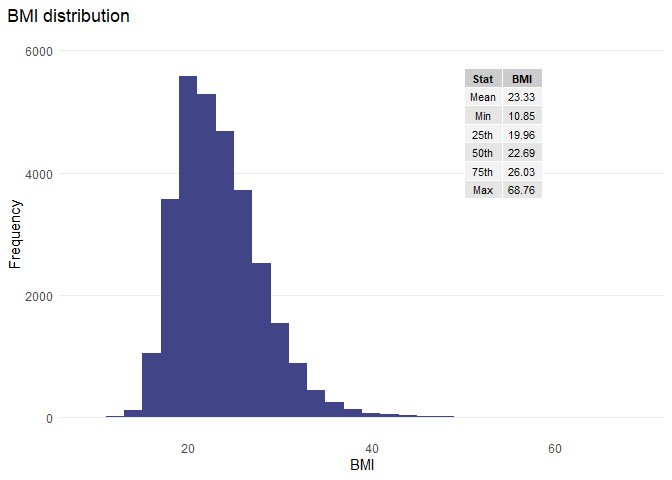

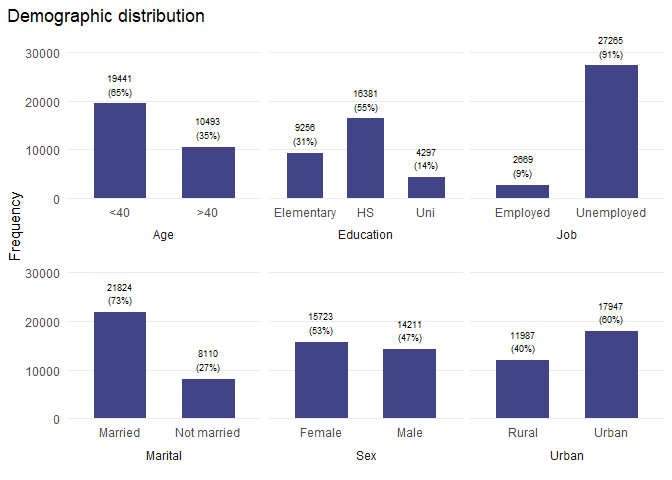

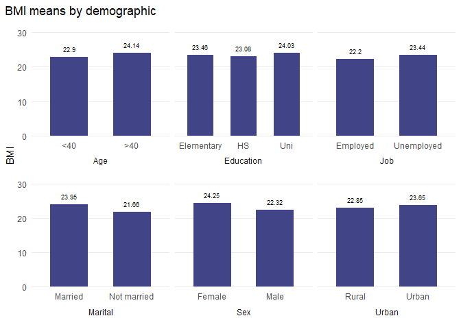

## Strata

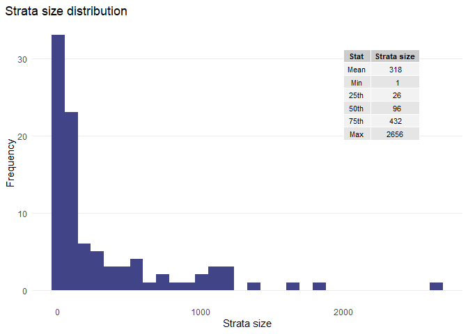

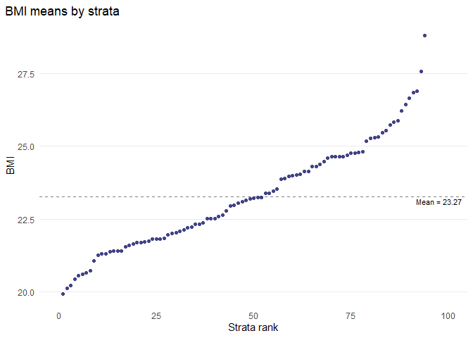

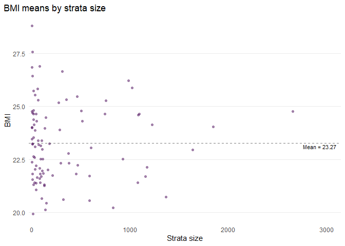

## Model fit

Model null measures the extent to which individual outcome heterogeneity is explained by sociodemographic intersections vs other factors. Optimally predicts the mean outcome for each stratum.

Model full decomposes sociodemographic mean outcomes into additive and non-additive effects and measures relative importance of interactions. Optimally predicts the strata interaction effects with built in control for type I errors of inference.

Model is fitted by maximum likelihood estimation (MLE).

[output not shown]

| Measure | Value |
| --- | --- |
| VPC | 13.62% |
| VPC adj | 3.04% |
| PCV | 80.15% |

The VPC adjusted is just 3.04% which is too little for interaction effects to explain the variation.

Percentage change in variance (PCV) measures the degree to which we explain the overall sociodemographic variation by just the main effects. The variation of sociodemographic main effects is 80.15%, and thus only 19.85% of the variation explained by sociodemographic interaction effects.

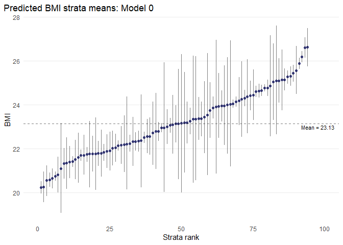

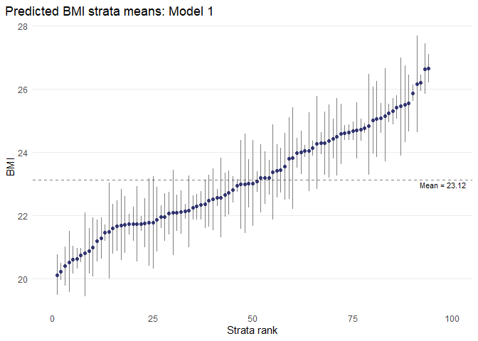

The caterpillar plot gives a sense of not just the variablity in predicted strata means, but their individual imprecision, and their lack of statistical separation.